# Diversidad morfológica en Aves y su posible relación con diversos modos del desarrollo

José Antonio Palma Liberona

07-01-2021

# 1 Introducción

Las Aves son un grupo de Vertebrados enormemente diverso representado por más de 10.000 especies y cubriendo 165-150 millones de años de historia evolutiva (Brusatte, O’Connor, and Jarvis 2015). Esta diversidad se expresa no solo en el número de especies sino que también en un amplio rango de tamaños corporales, diversos modos de locomoción (Gatesy and Dial 1996), diferentes proporciones de extremidades (Gatesy and Middleton 1997) y modos del desarrollo (Starck and Ricklefs 1998), siendo este último punto de particular interés para el presente trabajo.

El desarrollo Aviano ha sido clasificado acorde tanto a rasgos etológicos como morfológicos definiendose un espectro de modos del desarrollo que va desde super-precocial, crías con ausencia absoluta de cuidado parental y capaces de locomoción; a precocial, crías capaces de locomoción al poco tiempo de eclosionar con diversos niveles de cuidado parental; a semi-precocial, crías capaces de locomoción que se mantienen dentro del nido y son protejidas por los parentales; a semi-altricial, crías que nacen sin la capacidad de libre locomoción, a altricial, crías incapaces de locomoción y que nacen con los ojos cerrados; a super-altricial, crías que nacen sin capacidad locomotora además de con los ojos cerrados y sin plumaje (Starck and Ricklefs 1998; Botelho and Faunes 2015). Las consecuencias de esta diversidad de modos del desarrollo no se restringe a las condiciones de la cría al eclosionar y tiene efectos duraderos en los patrones de crecimiento, metabolismo (Vleck and Vleck 1980), complejidad de la estructura social (Scheiber et al. 2017) y modos de vuelo (Shatkovska and Ghazali 2017) entre otras.

Dado el amplio rango de efectos que el modo de desarrollo de Aves puede tener no es sorprendente que efectos sobre la morfología de las alas hayan sido reportados (Shatkovska and Ghazali 2017). No obstante, hasta ahora no se han descrito efectos de los modos del desarrollo sobre el posible rango de planes corporales presentes en Aves.

En el presente trabajo se buscó como mejor explicar la diversidad de planes corporales encontrada en Aves. Para esto se utilizó la razón entre el largo de ala y de tarso para aproximar esta diversidad y se buscó el mejor modelo para esta diversidad considerando variables relacionadas con los modos de alimentación (largo, ancho y lato del pico), la posición filogenética (Orden), el desarrollo (modo de desarrollo y estadio) y otras medidas morfológicas (largo de cola y peso). Para esto se generó una base de datos de 9.649 medidas de Aves a partir de dos bases de datos de aves sudamericanas publicadas (Montoya et al. 2018; Rodrigues et al. 2019).

# 2 Hipotesis

Debido a su efecto en el restringir o posibilitar patrones de crecimiento extremo, la variable de modo del desarrollo estará presente en el mejor modelo siendo crucial en poder explicar la diversidad de planes corporales.

# 3 Métodos

## 3.1 Preparación del set de datos

Partiendo de los set de datos publicados en (Montoya et al. 2018) y (Rodrigues et al. 2019) se procedió a seleccionar un subset de 7 variables morfológicas comunes a ambos sets y se curó la base de datos manteniendo solo aquellas observaciones que presentasen valores para todas las variables, además de un estadio ontogenético definido, resultando esto en las 9.649 observaciones previamente reportadas. Posteriormente, el modo de desarrollo para cada observación fue asignado acorde a lo publicado en (Botelho and Faunes 2015) con la salvedad de que no se hicieron distinciones entre aves semi-precociales y precociales debido a la ausencia de diferencias morfológicas entre estos modos de desarrollo (Vleck and Vleck 1980), adicionalmente el set de datos no presenta ninguna observación correspondiente a aves super-precociales. Con el fin de eliminar el efecto de los distintos tamaños corporales sobre las mediciones consideradas estas fueron normalizadas por el peso reportado para cada ave, el cual es un buen proxy de tamaño. Finalmente se construyo la variable respuesta a considerar dividiendo el largo de ala normalizado por el largo de tarso normalizado, esto con el fin de aproximar las proporciones de alas y piernas (las cuales están altamente relacionadas con el plan corporal) en una única variable.

# 4 Resultados

Tras evaluar la relación entre las variables continuas consideradas y la variable respuesta generada se observó que el largo de la cola presenta una relación asintótica con esta variable (4.1), por esto se decidió invertir estos valores a modo de linearizarlos.

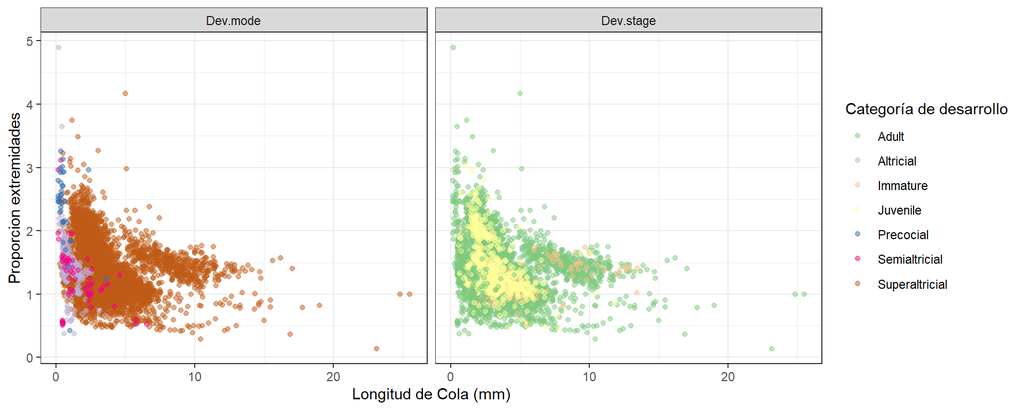

Figure 4.1: Gráfico de puntos que ilustra la relación entre la variable Proporcion corporal y largo de cola

Una vez invertida esta variable se procedió a evaluar el grado de correlación entre las variables continuas consideradas encontrandose una alta corelación entre el alto y ancho del pico (4.1) razón por la que se decidió excluir estas variables del mismo modelo.

Table 4.1: Correlación entre variables continuas consideradas

|  | Bill.length | Bill.depth | Bill.width | Inv.tail |
| --- | --- | --- | --- | --- |
| Bill.length |  |  |  |  |
| Bill.depth | 0.5268881 |  |  |  |
| Bill.width | 0.4592725 | 0.7103197 |  |  |
| Inv.tail | -0.3889197 | -0.5394948 | -0.4668648 |  |

Table 4.2: Modelos de explicacion de la diversidad morfologica en Aves

| R.cuadrado medio | SD.R.cuadrado | Modelos |
| --- | --- | --- |
| 0.3184618 | 0.0419337 | Prop ~ (Bill.length + Bill.width + Inv.tail):Order |
| 0.3112957 | 0.0682725 | Prop ~ (Bill.length + Bill.width + Inv.tail):Dev.mode:Order |
| 0.2914752 | 0.0483789 | Prop ~ (Bill.length + Bill.width + Inv.tail):Dev.mode:Dev.stage:Order |
| 0.2733406 | 0.0670036 | Prop ~ (Bill.length + Bill.width + Inv.tail):Dev.mode |
| 0.2614202 | 0.0643758 | Prop ~ (Bill.length + Bill.width + Inv.tail):Dev.stage:Order |
| 0.2436053 | 0.0117421 | Prop ~ (Bill.length + Bill.width + Inv.tail):Dev.stage |
| 0.2390937 | 0.0887991 | Prop ~ (Bill.length + Bill.width + Inv.tail):Dev.mode:Dev.stage |
| 0.2339234 | 0.0150120 | Prop ~ Bill.length + Bill.width + Inv.tail |
| 0.2171085 | 0.0298505 | Prop ~ (Bill.length + Bill.depth + Inv.tail):Dev.mode:Order |
| 0.2008652 | 0.0265551 | Prop ~ (Bill.length + Bill.depth + Inv.tail):Dev.mode |
| 0.1986826 | 0.0617668 | Prop ~ (Bill.length + Bill.depth + Inv.tail):Dev.mode:Dev.stage:Order |
| 0.1939702 | 0.0272250 | Prop ~ (Bill.length + Bill.depth + Inv.tail):Dev.stage:Order |
| 0.1887134 | 0.0599765 | Prop ~ (Bill.length + Bill.depth + Inv.tail):Order |
| 0.1835882 | 0.0666911 | Prop ~ (Bill.length + Bill.depth + Inv.tail):Dev.mode:Dev.stage |
| 0.1692667 | 0.0108341 | Prop ~ (Bill.length + Bill.depth + Inv.tail):Dev.stage |
| 0.1645584 | 0.0369108 | Prop ~ Bill.length + Bill.depth + Inv.tail |

En base a los resultados arriba presentados se observa que el mejor modelo es el que considera los parámetros de largo y ancho de pico, el inverso del largo de la cola y la interacción de estas variables con el Orden al que pertenecen las distintas aves, indicando un fuerte componente filogenético en la diversidad morfológica. No obstante este modelo es bastante deficiente al considerar el valor de R cuadrado asociado alcanza solo un 31% de la varianza observada por lo que lo más probable es que otros factores no considerados en este análisis expliquen mejor a los datos observados.

# 5 Conclusiones

Si bien el análisis aquí presentado es una primera aproximación a evaluar los factores que permiten explicar la diversidad morfológica observada en Aves, es claro dado los resultados obtenidos que las variables consideradas no son suficientes o que la medida de diversidad morfológica utilizada es deficiente. No obstante los resultados aquí obtenidos reafirman, aunque sea débilmente, que la estrategia de desarrollo puede cumplir un rol en explicar esta diversidad, puesto que el segundo mejor modelo considera esta variable (4.2). Otra posible aproximación a este problema sería el uso de métodos de clasificación de estrategias del desarrollo en base a rasgos morfológicos, permitiendo esto evaluar si la morfología permite identificar el modo de desarrollo, no obstante se optó por la presente estrategia dado que el presente curso se centró en modelos de regresión por sobre clasificación y que este metodo ya fue aplicado en un informe de otro curso.

# Referencias

Botelho, João Francisco, and Macarena Faunes. 2015. “The evolution of developmental modes in the new avian phylogenetic tree.” *Evolution & Development* 17 (4): 221–23. https://doi.org/10.1111/ede.12126.

Brusatte, Stephen L., Jingmai K. O’Connor, and Erich D. Jarvis. 2015. “The Origin and Diversification of Birds.” *Current Biology* 25 (19): R888–R898. https://doi.org/10.1016/j.cub.2015.08.003.

Gatesy, Stephen M., and Kenneth P. Dial. 1996. “Locomotor modules and the evolution of the Avian flight.” *Evolution* 50 (1): 331–40. https://doi.org/10.1111/j.1558-5646.1996.tb04496.x.

Gatesy, Stephen M., and Kevin M. Middleton. 1997. “Bipedalism, flight, and the evolution of theropod locomotor diversity.” *Journal of Vertebrate Paleontology* 17 (March 2013): 308–29. https://doi.org/10.1080/02724634.1997.10010977.

Montoya, Paola, Mailyn A. Gonzalez, Elkin A. Tenorio, Juan Pablo López-Ordóñez, Alejandro Pinto Gómez, Diego Cueva, Aldemar A. Acevedo Rincón, et al. 2018. “A morphological database for 606 Colombian bird species.” *Ecology* 99 (7): 1693–3. https://doi.org/10.1002/ecy.2368.

Rodrigues, Rodolpho Credo, Érica Hasui, Julia Camara Assis, João Carlos Castro Pena, Renata L. Muylaert, Vinicius Rodrigues Tonetti, Felipe Martello, et al. 2019. “Atlantic bird traits: a data set of bird morphological traits from the Atlantic forests of South America.” *Ecology*, April, e02647. https://doi.org/10.1002/ecy.2647.

Scheiber, Isabella B. R., Brigitte M. Weiß, Sjouke A. Kingma, and Jan Komdeur. 2017. “The importance of the altricial – precocial spectrum for social complexity in mammals and birds – a review.” *Frontiers in Zoology* 14 (1): 3. https://doi.org/10.1186/s12983-016-0185-6.

Shatkovska, O. V., and M. Ghazali. 2017. “Relationship between developmental modes, flight styles, and wing morphology in birds.” *The European Zoological Journal* 84 (1): 390–401. https://doi.org/10.1080/24750263.2017.1346151.

Starck, J. M., and R. E. Ricklefs, eds. 1998. *Avian Growth and Development. Evolution within the altricial precocial spectrum*. New York: Oxford University Press.

Vleck, Carol Masters, and David Vleck. 1980. “Patterns of Metabolism and Growth in Avian Embryos.” *American Zoologist* 20 (2): 405–16. https://doi.org/10.1093/icb/20.2.405.